# Part I - EXPLORATION OF LOAN DATA DATASET

## by (Robert Kipchumba Korir)

## Introduction

> The dataset I was working on is the 'Loan Data from Prosper' dataset. It is a relatively large datsaet with alot of variables. It contains loans data from the year 2005 up until 2014. For my approach only a few of the aforementioned variables will be explored. The purpose of this analysis is to investigate the yearly trends in loans borrowed, factors affecting the BorrowerRates and borrowing trends among various categories (eg. Homeownership, Employment status etc.) My study will seek to answer questions like:

> How does the distribution of Loan Interest rates look like? How do different employment statuses rank ? How is the distribution of loan amounts(`LoanOriginalAmount`) borrowed? What are the yearly trends of loan amounts borrowed What categories of people are seen to borrow the most loans? What is the distribution of loan `Investors`?

> For this analysis I will focus mostly on the following variables `LoanOriginalAmount`,`Investors`,`BorrowerRate`,`BorrowerAPR`,`LoanOriginationQuarter`, `StatedMonthlyIncome`,`IsBorrowerHomeowner`,`EmploymentStatus`,`InvestmentFromFriendsAmount` I will require to engineer new meaningful features too like `YearBorrowed`

```python
# import all packages and set plots to be embedded inline
import numpy as np
import pandas as pd
import matplotlib.pyplot as plt
import seaborn as sb
from pandas.api.types import CategoricalDtype

%matplotlib inline

import warnings
warnings.simplefilter("ignore")
```

> Load in your dataset and describe its properties through the questions below. Try and motivate your exploration goals through this section.

```python
loans = pd.read_csv('prosperLoanData.csv')
loans.shape
```

```
(113937, 81)
```

```python
var_focus = ['ListingKey','ListingNumber','ListingCreationDate','CreditGrade','Term','LoanStatus',
             'ClosedDate','BorrowerAPR','BorrowerRate',r'ProsperRating (Alpha)',r'ListingCategory (numeric)',
             'BorrowerState','Occupation','EmploymentStatus','IsBorrowerHomeowner','CurrentlyInGroup',
             'GroupKey','IncomeRange','StatedMonthlyIncome','LoanKey','LoanNumber','LoanOriginalAmount',
             'LoanOriginationQuarter','InvestmentFromFriendsCount','InvestmentFromFriendsAmount','Investors']
loans_sub  = loans[var_focus]
loans_sub['YearBorrowed'] = loans_sub['LoanOriginationQuarter'].str[3:]
print(loans_sub.shape)
```

```
(113937, 27)
```

```python
#Change the variables 'prosperRating' into Categorical variables
ratings = ['HR','E','D','C','B','A','AA']
years = CategoricalDtype(['2005','2006','2007','2008','2009','2010','2011','2012','2013','2014'], ordered = True)
prospRt = CategoricalDtype(ratings, ordered = True)
ln_status = CategoricalDtype(['Current','Completed','FinalPaymentProgress',r'PastDue(1-15 days)',r'PastDue(16-30 days)',
                              r'PastDue(31-60 days)',r'PastDue(61-90 days)',r'PastDue(91-120 days)',r'PastDue(>120 days)',
                              'Chargedoff','Defaulted','Cancelled'], ordered = True)

loans_sub[r'ProsperRating (Alpha)'] = loans_sub[r'ProsperRating (Alpha)'].astype(prospRt)
loans_sub['YearBorrowed'] = loans_sub['YearBorrowed'].astype(years)
loans_sub['LoanStatus'] = loans_sub['LoanStatus'].astype(ln_status)
```

```python
(loans_sub['LoanStatus']).dtype
```

```
CategoricalDtype(categories=['Current', 'Completed', 'FinalPaymentProgress',
                  'PastDue(1-15 days)', 'PastDue(16-30 days)',
                  'PastDue(31-60 days)', 'PastDue(61-90 days)',
                  'PastDue(91-120 days)', 'PastDue(>120 days)', 'Chargedoff',
                  'Defaulted', 'Cancelled'],
, ordered=True)
```

### What is the structure of your dataset?

> My dataset was initially of shape (113937, 81) but after selecting specific columns, I trimmed it to (113937, 27)

### What is/are the main feature(s) of interest in your dataset?

> The main features of my dataset are `BorrowerRate` , `LoanOriginalAmount`, `EmploymentStatus`

### What features in the dataset do you think will help support your investigation into your feature(s) of interest?

> The features that may help in supporting my investigation include `LoanOriginationQuarter`,`Investors`,`StatedMonthlyIncome` among plenty others

## Univariate Exploration

> In this section, I will investigate distributions of individual variables within the dataset.

```python
#since the lowest value is zero and its log is undefined, we try and get the minimum non zero value
loans_sub2 = loans_sub.loc[loans_sub['StatedMonthlyIncome'] != 0]
np.log10(loans_sub2.StatedMonthlyIncome.describe())
```

[output not shown]

## How does the distribution of StatedMonthlyIncome borrowed look like?

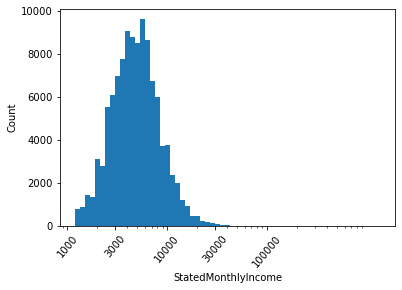

```python
#histogram function
def histplt(df, x, bin_vals,log):
    if (log == True):
        bins = 10 ** np.arange(bin_vals[0],bin_vals[1] + bin_vals[2], bin_vals[2])
        plt.xscale('log')
    else:
        bins = np.arange(bin_vals[0],bin_vals[1] + bin_vals[2], bin_vals[2])
    plt.hist(data = df, x = x, bins = bins)
    plt.xlabel(x)
    plt.ylabel('Count');

histplt(loans_sub, 'StatedMonthlyIncome', [3.08,6.1,0.05], True)
ticks = [1000,3000,10000, 30000, 100000]
labels = ['{}'.format(v) for v in ticks]
plt.xticks(ticks, labels, rotation = 50);
```

From the plot above, the distribution of `StatedMonthlyIncome` is unimodal, with alot of the values falling at around 5000

I was required to log transform the x axis because the initial plot without transformation appeared to have a long tail.

## How do different employment statuses rank ?

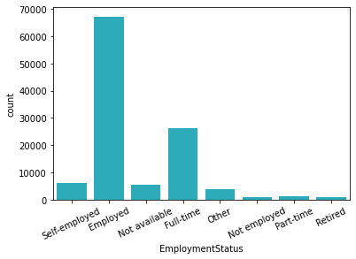

```python
base_color = sb.color_palette()[-1]
sb.countplot(data = loans_sub, x = 'EmploymentStatus', color = base_color)
plt.xticks(rotation = 25);
```

From the plot above, it is clear that loans are mostly borrowed by employed people.

## How does the distribution of Loan Interest rates look like?

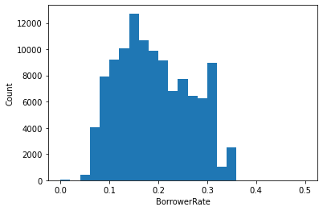

```python
histplt(loans_sub, 'BorrowerRate', [0,0.5,0.02],False);
```

## How do the counts of different Loan statuses compare

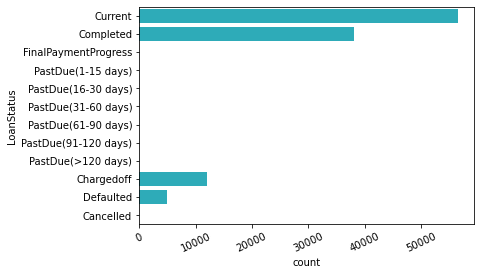

```python
base_color = sb.color_palette()[-1]
sb.countplot(data = loans_sub, y = 'LoanStatus', color = base_color)
plt.xticks(rotation = 25);
```

Loans with interest rates of around 0.15 are the the most common.

Very few of the loans borrowed are delinquent at the time of recording the data (`Past Due` columns are very low across the bar graph)

```python
#getting the bin ranges!
print(loans_sub['LoanOriginalAmount'].describe())
np.log10(loans_sub.LoanOriginalAmount.describe())
```

```
count    113937.00000
mean       8337.01385
std        6245.80058
min        1000.00000
25%        4000.00000
50%        6500.00000
75%       12000.00000
max       35000.00000
Name: LoanOriginalAmount, dtype: float64
```

```
count    5.056665
mean     3.921011
std      3.795588
min      3.000000
25%      3.602060
50%      3.812913
75%      4.079181
max      4.544068
Name: LoanOriginalAmount, dtype: float64
```

### How is the distribution of LoanOriginalAmount?

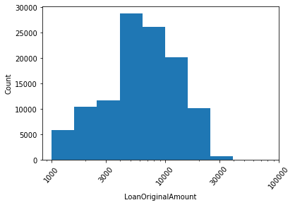

```python
vals = [3,4.5,0.2]
ticks = [1000,3000,10000, 30000, 100000]
histplt(loans_sub, 'LoanOriginalAmount',vals,True)
ticks = [1000,3000,10000, 30000, 100000]
labels = ['{}'.format(v) for v in ticks]
plt.xticks(ticks, labels, rotation = 50);
```

The distribution of the original loan amounts takes a normal distribution, as it the plot above shows, it is unimodal.

The amount that appears to have the largest count is around 4000

```python
loans_sub['Investors'].describe()
print(np.log10(loans_sub.Investors.describe()))
```

```
count    5.056665
mean     1.905662
std      2.013844
min      0.000000
25%      0.301030
50%      1.643453
75%      2.060698
max      3.075182
Name: Investors, dtype: float64
```

### Investigating the distribution of Investors

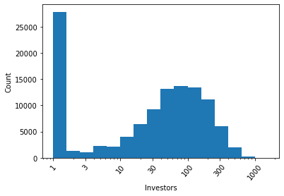

```python
histplt(loans_sub,'Investors',[0,3.08,0.2],True);
ticks = [1,3,10,30,100, 300, 1000]
labels = ['{}'.format(v) for v in ticks]
plt.xticks(ticks, labels, rotation = 50);
```

## Investigating the relationship between the BorrowerAPR variable and the LoanOriginalAmount

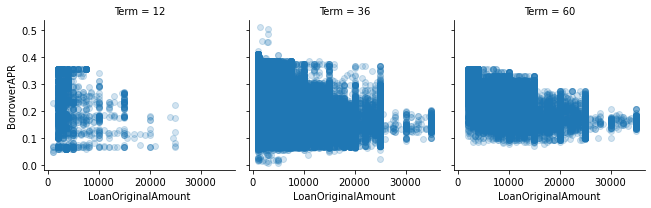

```python
g = sb.FacetGrid(data = loans_sub, col = 'Term', col_wrap = 4)
g.map(plt.scatter, 'LoanOriginalAmount','BorrowerAPR',alpha = 1/5);
```

From the plot above, you could conclude that generally, the interest rate for larger amounts is lower while for smaller amounts, it is larger.

## What is the relationship between the prosper rating and the amount of money borrowed?

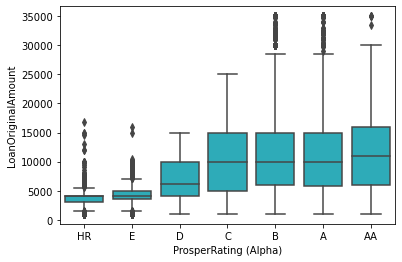

```python
base_color = sb.color_palette()[-1]
sb.boxplot(data = loans_sub, x = r'ProsperRating (Alpha)',
              y = 'LoanOriginalAmount', color = base_color);
```

From the boxplot above, we can deduce that the categories HR and E recorded lowest for Loan amount borrowed

For A category, for example, we can see that the median amount borrowed is 10000

## What is the relationship between the LoanAmount borrowed and the Terms set (months) for the loan?

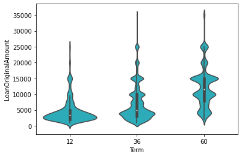

```python
sb.violinplot(data = loans_sub, x = 'Term',
              y = 'LoanOriginalAmount', color = base_color);
```

According to the violin plot above, the majority of loans fall within the 5000 mark. The median amount borowed for Terms 12 and 36 is around 4000 and 5000 respectively with for Term 60 it is around 12500

```python
loans_sub[['BorrowerRate', 'BorrowerAPR','LoanOriginalAmount']].describe()
```

|  | BorrowerRate | BorrowerAPR | LoanOriginalAmount |
| --- | --- | --- | --- |
| count | 113937.000000 | 113912.000000 | 113937.00000 |
| mean | 0.192764 | 0.218828 | 8337.01385 |
| std | 0.074818 | 0.080364 | 6245.80058 |
| min | 0.000000 | 0.006530 | 1000.00000 |
| 25% | 0.134000 | 0.156290 | 4000.00000 |
| 50% | 0.184000 | 0.209760 | 6500.00000 |
| 75% | 0.250000 | 0.283810 | 12000.00000 |
| max | 0.497500 | 0.512290 | 35000.00000 |

## Interest Rate and Borrower APR against LoanAmountBorrowed

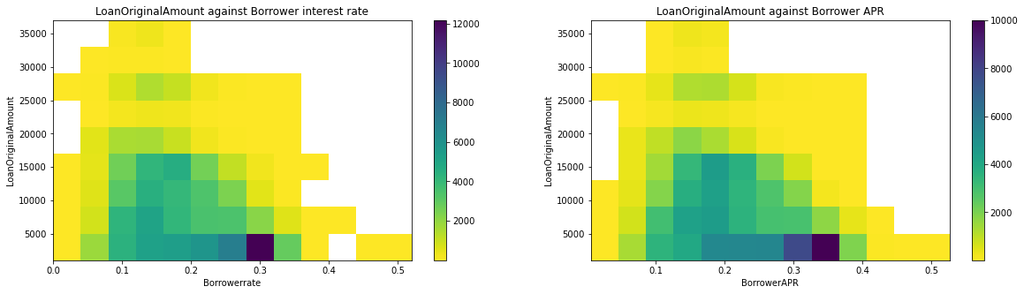

```python
plt.figure(figsize = [20,5])
plt.subplot(1,2,1)
bins_x = np.arange(0, 0.5 + 0.04, 0.04)
bins_y = np.arange(1000, 35000 + 4000, 4000 )
plt.hist2d(data = loans_sub, x = 'BorrowerRate', y = 'LoanOriginalAmount',
           cmin = 0.5,cmap = 'viridis_r',bins = [bins_x,bins_y] )
plt.ylabel('LoanOriginalAmount')
plt.xlabel('Borrowerrate')
plt.title('LoanOriginalAmount against Borrower interest rate')
plt.colorbar()
plt.subplot(1,2,2)
bins_x2 = np.arange(0.006,0.51 + 0.04,0.04)
plt.hist2d(data = loans_sub, x = 'BorrowerAPR', y = 'LoanOriginalAmount',
          cmin = 0.5, cmap = 'viridis_r', bins = [bins_x2,bins_y])
plt.ylabel('LoanOriginalAmount')
plt.xlabel('BorrowerAPR')
plt.title('LoanOriginalAmount against Borrower APR')
plt.colorbar();
```

The heatmap above shows that alot of the loans fall between amounts 0 and 15000, with the most values falling where the interest rates and APR is around 0.3 and 0.3-0.4 respectively This heatmap shows exactly how closely related the two variables `Borrowerrate` and `BorrowerAPR` are.

## What is the relationship between the number of Investors and LoanOriginalAmount?

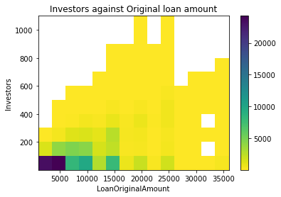

```python
bins_x = np.arange(1000, 34000 + 2500, 2500)
bins_y = np.arange(1, 1100 + 100, 100)
plt.hist2d(data = loans_sub, x = 'LoanOriginalAmount',y = 'Investors',
           cmin = 0.5,cmap = 'viridis_r',bins = [bins_x,bins_y])
plt.title('Investors against Original loan amount')
plt.xlabel('LoanOriginalAmount')
plt.ylabel('Investors')
plt.colorbar();
```

From the above plot, you could deduce that the loans with few investors and borrowing around 5000 dollars are in the majority Loans with more investors involve larger sums of money borrowed and are in the minority

## What is the relationship between InvestmentFromFriendsAmount and Investors?

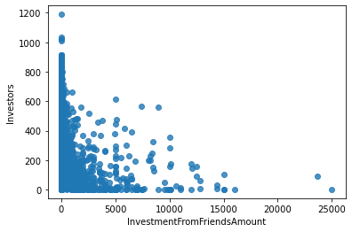

```python
sb.regplot(data = loans_sub, x = 'InvestmentFromFriendsAmount', y = 'Investors', fit_reg = False);
```

From the plot above, it seems like the amount contributed by investors is mostly inversely proportional to the amounts they contribute.

## What is the relationship between the 'YearBorrowed' variable and the LoanOriginalAmount?

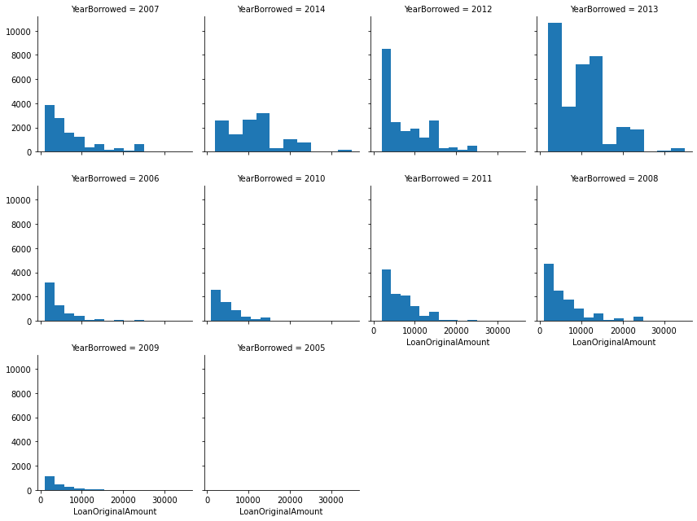

```python
g = sb.FacetGrid(data = loans_sub, col = 'YearBorrowed', col_wrap = 4,  sharey = True)
g.map(plt.hist, 'LoanOriginalAmount');
```

From the faceted plot above, 2013 seems to be the year with the highest amount of loans given out, with majority of them being smaller loans. 2005 barely has any loan data available hence the blank plot.

## Investigating the pairwise relationships between the numeric variables

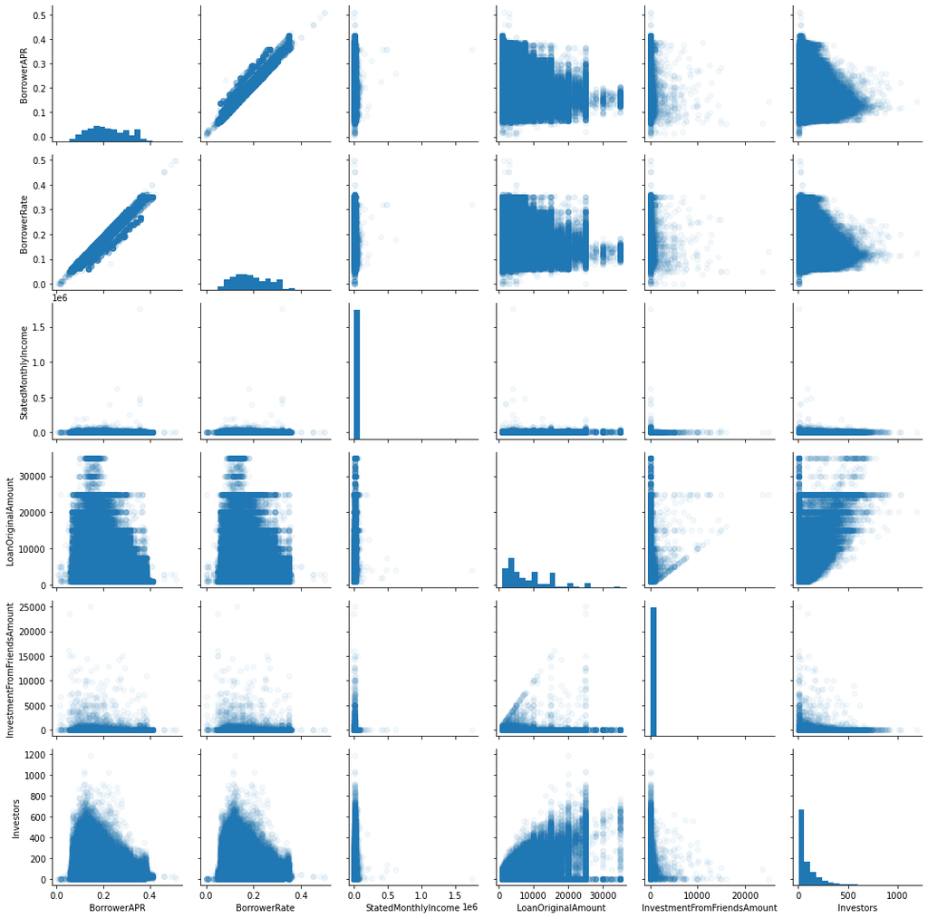

```python
numeric_vars = ['BorrowerAPR','BorrowerRate','StatedMonthlyIncome','LoanOriginalAmount', 'InvestmentFromFriendsAmount', 'Investors']
loans_samp = loans_sub.sample(n = 300, replace = False)

g = sb.PairGrid(data = loans_sub, vars = numeric_vars)
g = g.map_diag(plt.hist, bins = 20,)
g.map_offdiag(plt.scatter, alpha = 1/20);
```

As expected, The variables BorrowerRate and BorrowerAPR are highly correlated Investors seems to be directly proportional to the LoanOriginalAmount which is worth exploring. There doesnt seem to be much investment from friends judging from how straight its scatter plot is on both axes

## Investigating the loan amounts borrowed agaisnt Employment status, considering whether the person is a homeowner or not

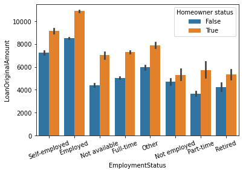

```python
ax = sb.barplot(data = loans_sub, x = 'EmploymentStatus', y = 'LoanOriginalAmount', hue = 'IsBorrowerHomeowner')
ax.legend(title = 'Homeowner status')
plt.xticks(rotation = 20);
```

From the plot above, it can be deduced that the employed people tend to make the highest loans. It is also clear that Homeowners always borrow more than the non Homeowners